# Ngrams analysis and NPL modelling

Marco Letico

February 17, 2018

## Summary

The goal of this project is just to display that we’ve gotten used to working with the data and that we are on track to create our prediction algorithm. This document should be concise and explain only the major features of the data we have identified and briefly summarize our plans for creating the prediction algorithm and Shiny app in a way that would be understandable to a non-data scientist manager. We should make use of tables and plots to illustrate important summaries of the data set. The motivation for this project is to: 1. Demonstrate that we’ve downloaded the data and have successfully loaded it in. 2. Create a basic report of summary statistics about the data sets. 3. Report any interesting findings that we amassed so far. 4. Get feedback on our plans for creating a prediction algorithm and Shiny app.

## Getting the data

For this analysis we will use the following package: `stringr` package is used to clean and manipulate the data. The `quanteda` package is the main package we use for NPL processing. We decided to use this package because it seems is more faster than `RWeka` and it doesn’t remove automatically the punctuation while performing tokenizations. Finally `ggplot2`, `gridExtra` and `wordcloud2` are used for the visualization of the results.

```r
library(stringr)
library(quanteda)
library(ggplot2)
library(gridExtra)
library(wordcloud2)
```

For exploratory data analysis purpose, we will also create a unique file containing all the three different files:

```r
if(!exists("Data")){dir.create("Data")}
fileUrl <- "https://d396qusza40orc.cloudfront.net/dsscapstone/dataset/Coursera-SwiftKey.zip"
download.file(fileUrl, destfile = ".\\Data\\Coursera-SwiftKey.zip")
unzip(zipfile = ".\\Data\\Coursera-SwiftKey.zip", exdir = ".\\Data")

twitter <- readLines(".\\Data\\final\\en_US\\en_US.twitter.txt")
blogs <- readLines(".\\Data\\final\\en_US\\en_US.blogs.txt")
news <- readLines(".\\Data\\final\\en_US\\en_US.news.txt")

files <- unlist(list(twitter, blogs, news))
```

Files consist of the following information. Here we are going to calculate the length of the files, consisting in the number of rows for each file.

```r
lengths <- data.frame(c("twitter", "blogs", "news"),
                      c(length(twitter), length(blogs), length(news)))
colnames(lengths) <- c("source", "rowsCount")

g1 <- ggplot(lengths, aes(x = reorder(source, -rowsCount), y = rowsCount))
g1 <- g1 + geom_bar(stat = "identity", fill = c("#E69F00", "#56B4E9", "#999999"),
                    colour="black")
g1 <- g1 + ggtitle("Number of rows in the text") + xlab("Source") + ylab("Count")
g1 <- g1 + geom_text(aes(label=lengths$rowsCount), vjust=-0.3, size=3.5)
```

```r
twitterWords <- str_replace_all(twitter,"[^a-zA-Z]", " ")
twitterWords <- sum(str_count(twitter, "\\S+"))

blogsWords <- str_replace_all(blogs,"[^a-zA-Z]", " ")
blogsWords <- sum(str_count(blogs, "\\S+"))

newsWords <- str_replace_all(news,"[^a-zA-Z]", " ")
newsWords <- sum(str_count(news, "\\S+"))

counts <- data.frame(c("twitter", "blogs", "news"),
                     c(twitterWords, blogsWords, newsWords))
colnames(counts) <- c("source", "wordsCount")

g2 <- ggplot(counts, aes(x = reorder(source, -wordsCount), y = wordsCount))
g2 <- g2 + geom_bar(stat = "identity", fill = c("#56B4E9", "#E69F00", "#999999"),
                    colour="black")
g2 <- g2 + ggtitle("Number of words in the text") + xlab("Source") + ylab("Count")
g2 <- g2 + geom_text(aes(label=counts$wordsCount), vjust=-0.3, size=3.5)
```

Below we plot the data collected. We can notice that, meanwhile the “twitter” file has more rows, it has a less number of words than the “blogs” file. The weigth of the “news” file is not so big if compared to the other two, either in term of rows and words.

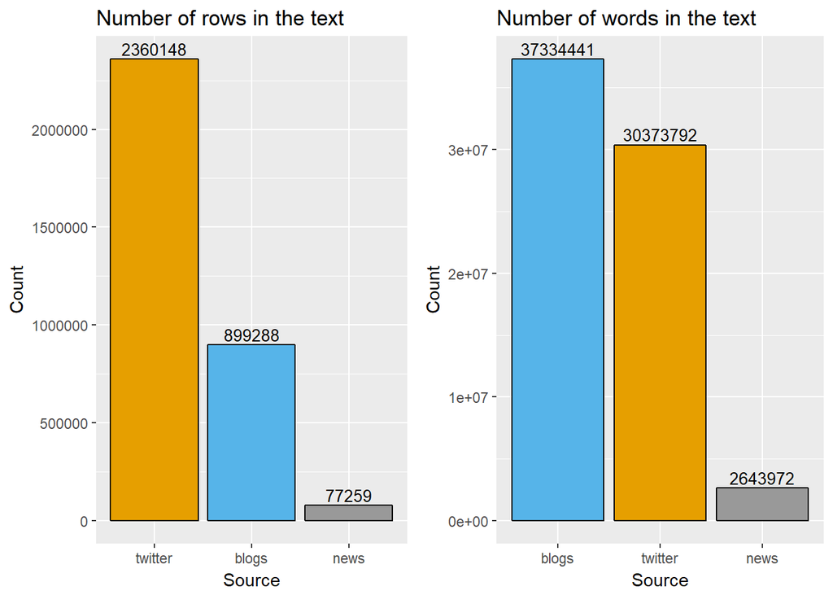

```r
grid.arrange(g1, g2, ncol = 2)
```

```r
set.seed(4783)
dataSample <- sample(files, length(files)*0.01)
```

## Cleaning the data

```
## [1] "How are you? Btw thanks for the RT. You gonna be in DC anytime soon? Love to see you. Been way, way too long."
```

```r
PrepareTheData <- function(text, unigram = FALSE) {
        require(stringr)
        text <- tolower(text)
        text <- str_replace_all(text,"#\\S+", " ")
        text <- str_replace_all(text,"(f|ht)tp(s?)://(.*)[.][a-z]+", " ")
        text <- str_replace_all(text,"\\.+", ". ")
        text <- str_replace_all(text,"\\?|\\!", ". ")
        if (!unigram) {
                text <- str_replace_all(text,"[^a-zA-Z\\.\\,\\']", " ")
        } else {
                text <- str_replace_all(text,"[^a-zA-Z\\.\\']", " ")
        }
        text <- str_replace_all(text,"\\ ' |\\' |\\ '", " ")
        text <- str_replace_all(text,"[\\s]+", " ")
        text <- str_replace_all(text," s ", "'s ")
        text <- str_replace_all(text," t ", "'t ")
        text <- str_replace_all(text," u ", " you ")
        text <- str_replace_all(text," $|\\.$|\\. $", "")
        text <- str_replace_all(text,"\\. ", ".")
        text <- str_replace_all(text,"\\, ", ",")
        text <- str_split(text, "\\.|\\,")
        text <- unlist(text)
        return(text)
}
```

After having obtained our personalized split, we are going to create the corpus with the `quanteda` package.

```r
unigramsData <- PrepareTheData(dataSample, unigram = TRUE)
multigramsData <- PrepareTheData(dataSample)
unigramsCorpus <- corpus(unigramsData)
multigramsCorpus <- corpus(unigramsData)
```

## Exploratory Data Analysis

Below, with the function `dfm`, we are going to create our document term matrix for unigrams, bigrams and trigrams.

```r
unigrams <- dfm(unigramsCorpus, ngrams = 1, concatenator = " ",
                remove = stopwords("english"), removePunct = FALSE)

bigrams <- dfm(multigramsCorpus, ngrams = 2, concatenator = " ",
               remove = stopwords("english"), removePunct = FALSE)

trigrams <- dfm(multigramsCorpus, ngrams = 3, concatenator = " ",
               remove = stopwords("english"), removePunct = FALSE)
```

## Visualization

Finally we are going to calculate the frequency of the top 50 most frequent n-grams with the function `textstat_frequency` and plot it. As we have to repeat it for 3 times, we created the following function to plot the histogram of the frequency. We add also the world cloud function to plot a nice world cloud.

```r
plotTopFeatures <- function(frequencyMatrix, wc = FALSE, n = 50, fill = "black", size = 1) {
        require(webshot)
        require(htmlwidgets)
        tempFrequencyMatrix <- textstat_frequency(frequencyMatrix, n = n)
    if (!wc){
        g <- ggplot(tempFrequencyMatrix, aes(x = reorder(feature, frequency), y = frequency))
        g <- g + labs(title = paste(deparse(substitute(n)), "top",
                        deparse(substitute(frequencyMatrix)), sep = " "),
                        x = "N-Gram", y = "Frequency")
        g + geom_bar(stat="identity", fill=fill, colour="black") + coord_flip()
    } else {
        fileName <- paste(deparse(substitute(frequencyMatrix)), "wordcloud.png", sep = "_")
        wcPlot <- wordcloud2(tempFrequencyMatrix, size = size)
        saveWidget(wcPlot, "tmp.html", selfcontained = F)
        webshot("tmp.html", fileName, delay = 30, vwidth = 2500, vheight = 1300)

    }

}
```

Finally we are showing below the 50 most frequent words in our data sample:

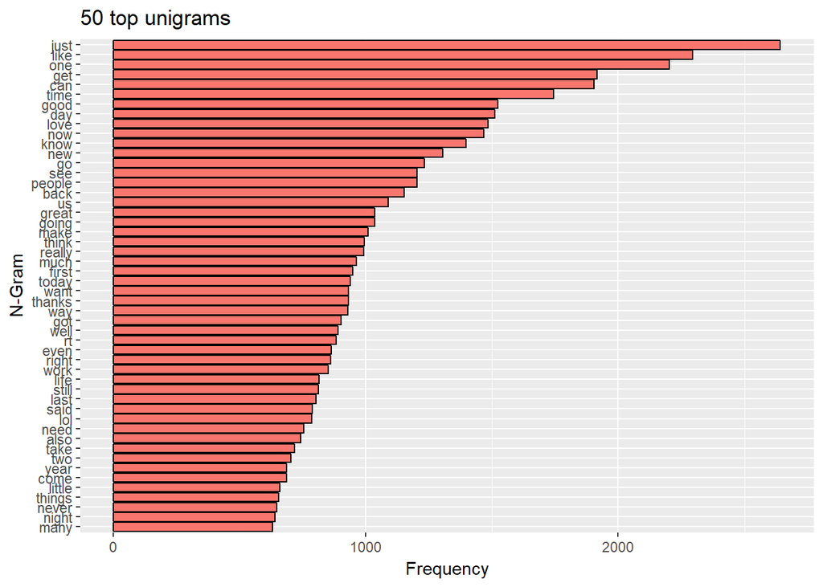

```r
plotTopFeatures(unigrams, fill = "#F8766D")
```

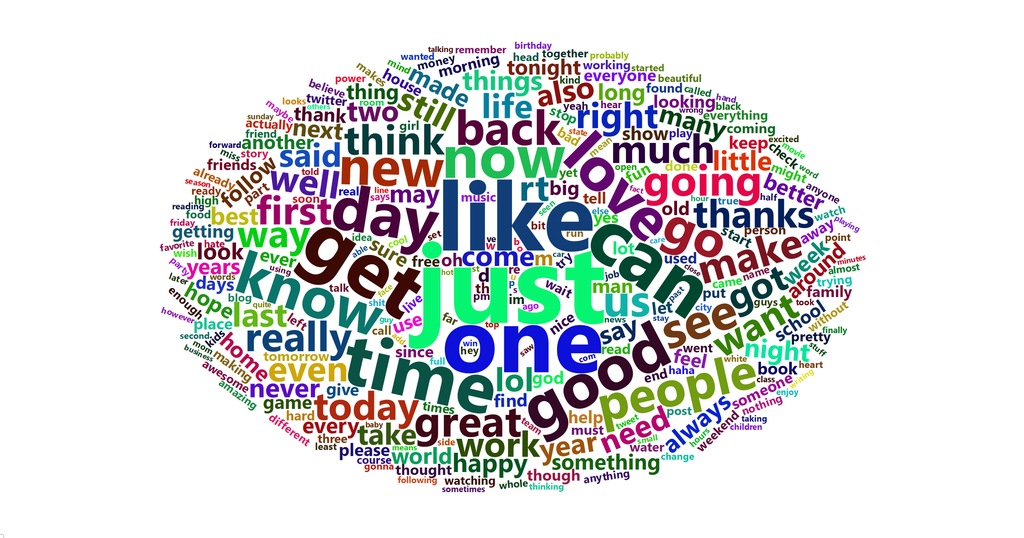

```r
plotTopFeatures(unigrams, n = 500, wc = T, size = 1.5)
```

Then we plot the bigrams:

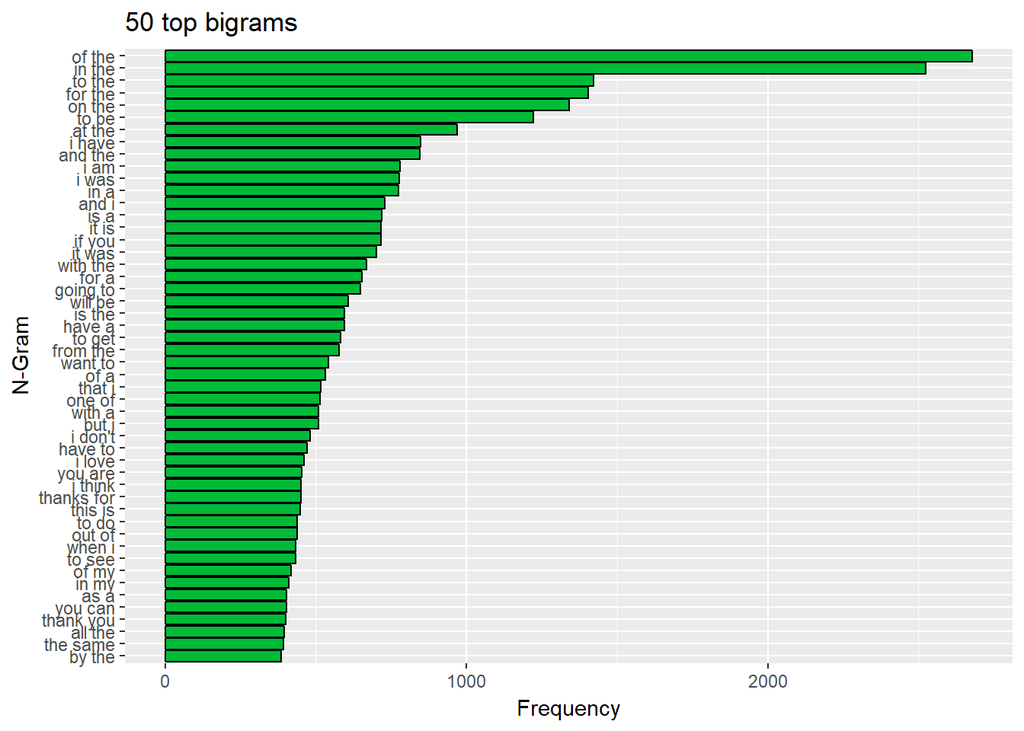

```r
plotTopFeatures(bigrams, fill = "#00BA38")
```

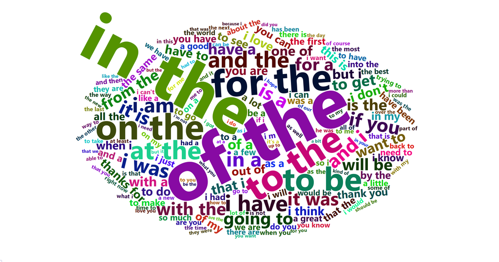

```r
plotTopFeatures(bigrams, n = 500, wc = T, size = 2)
```

And last but not least, is the turn of the trigrams:

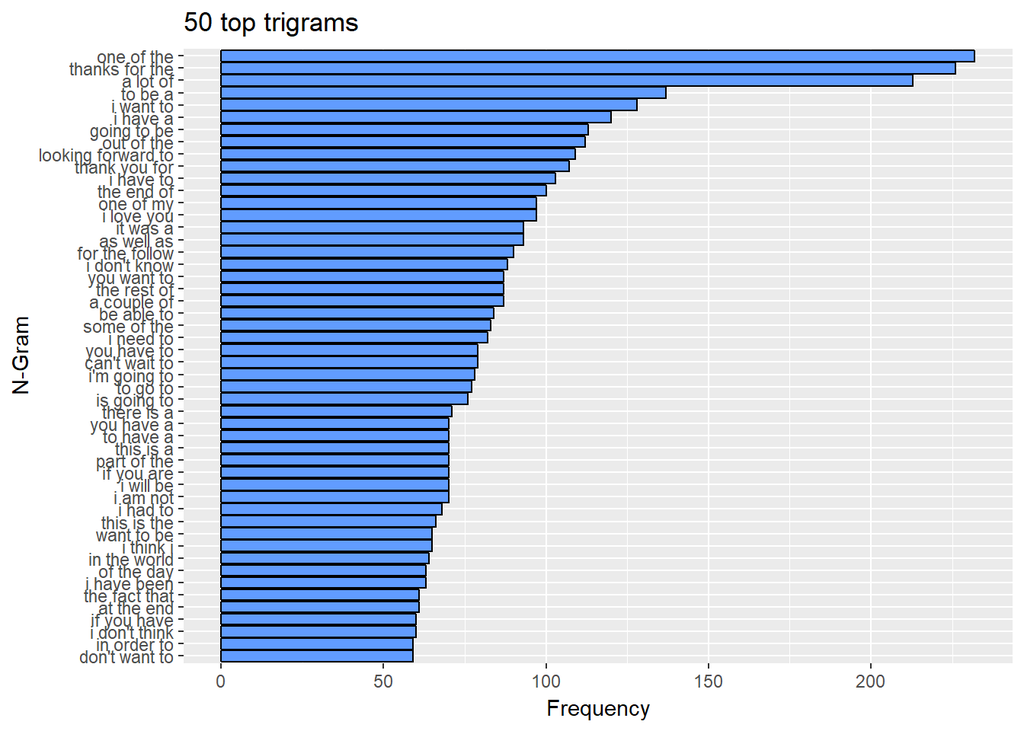

```r
plotTopFeatures(trigrams, fill = "#619CFF")
```

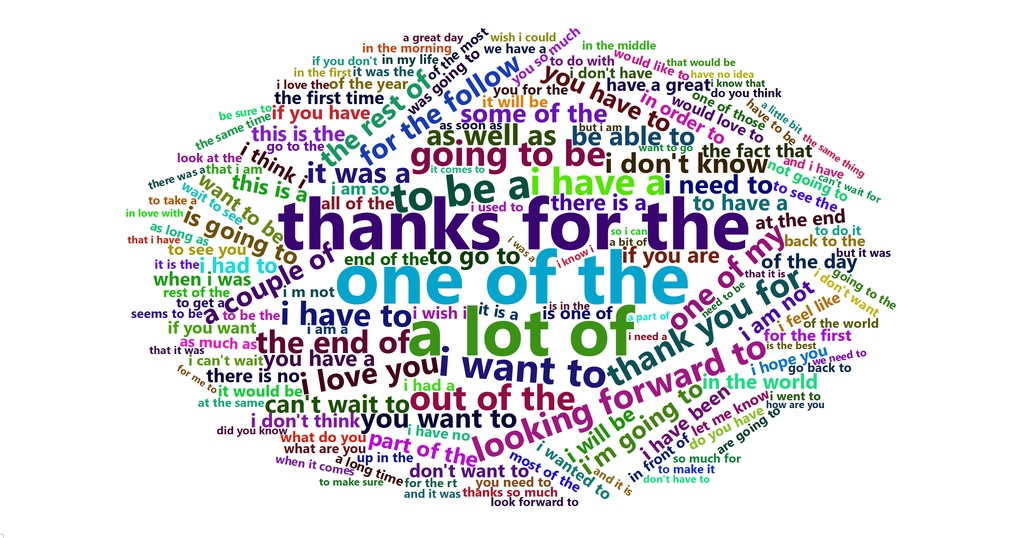

```r
plotTopFeatures(trigrams, n = 500, wc = T)
```

## Conclusions and further plans

This is a preliminary exploratory analysis. We saw the distributions of the words, bigrams and trigrams. Our aim will be to create a Shiny application where the user will be able to insert the text and receive some prediction regarding the next word. The models done here will be necessary to this scope.